# Support Vector Machines

## Introduction

Support vector machine (SVM) learning is a supervised learning technique which may be used as a classification system or to find regression formulae. Support Vector Machines were described by Vladimir Vapnik and Corinna Cortes in 1995 while at Bell Labs.[^1]

SVM is also **Non-parametric** approach to regression and classification. What is Non-parametric? For that matter, what is parametric learning and models. Just as we have learned that machine learning models can be supervised, unsupervised or even semi-supervised another characteristic between machine learning models is whether they are parametric or not.

In the Webster’s dictionary[^2] states a *parameter* is

> 1. Estimation of values which enter into the equation representing the chosen relation
> 2. [An] independent variable through functions of which other functions may be expressed - Frank Yates, a 20th century statistician

Another important distinction for understanding modern machine learning is the concept of parametric vs non-parametric.

> [D]oes the model have a fixed number of parameters, or does the number of parameters grow with the amount of training data? The former is called a parametric model, and the latter is called a non-parametric model. Parametric models have the advantage of often being faster to use, but the disadvantage of making stronger assumptions about the nature of the data distributions. Non-parametric models are more flexible, but often computationally intractable for large datasets.[^3]

Because SVM is a supervised learning the role of the independent variables and the role of the labels (as they are commonly called) or dependent variables plays an important role in the workings SVM. For mathematical purposes the labels are a set of 1 or -1.

Therefore, given a set of labeled pairs of data:

$$X \in R^{\large m \times n}, ~~where ~~~~matrix ~~X ~~has ~~m ~~rows ~~and ~~n ~~columns$$

The set of labeled training pairs,

$$\{(x_1, ~y_1),~ ...,~ (x_m, ~y_m)\},~~~ y_i \in \{1, ~-1\}$$

so we may write

$$~~~f(x_i) = \left\{ \begin{array}{cc} \geq 0; ~y_i = 1 \\ ~< 0; ~y_i = -1 \end{array} \right\}$$

The idea guiding SVM is a geometric one.

Big O notation

[output not shown]

SVM {caret} / https://rpubs.com/PranovMishra/476455

In the case of this work, the SVM inputs consist of a set of a labeled pair of data, $(X, Y)$.

> 1. SVMs construct a maximum margin separator they retain training examples and potentially need to store them all. On the other hand, in practice they often end up retaining only a small fraction of the number of examples25.

Such that $~f(x_i) = \left\{ \begin{array}{cc} \geq 0; ~y_i = 1 \\ ~< 0; ~y_i = -1 \end{array} \right\}$

where $~~y~~$ is a set of two values which indicate a label, e.g. true or false.

min $\frac{1} {2} W^{T} W ~~+~~ C ~ \sum_{i=1}^l \xi_i$

subject to $~~y_i (w^T \phi (x_i) ~+~ b) \geq (1 - \xi_i)$ where $~\xi_i \geq 0$,

$C$ is the penalty parameter, *cost*, of the error term, such that $C > 0$.

Furthermore, $K(x_i, x_j) ~~\equiv~~ \phi (x_i)^T \phi (x_j)$ is called the kernel function.

The 4 most common SVM formulae are:

1. Linear: $K(x_i, ~y_j) ~~=~~ <x, ~y>$
   - The linear kernel does not transform the data at all.
2. Polynomial: $K(x_i, x_j) ~~=~~ ( \gamma ~x_i^T ~x_j ~~+~~ r)^{d}, ~\gamma > 0$
   - The polynomial kernel has a simple non-linear transform of the data.
3. Radial Basis Function (RBF): $K(x_i, x_j) ~~=~~ exp ( - \gamma \parallel x_i^T - x_j \parallel ^2 ), ~\gamma >0$
   - The Gaussian RBF kernel which performs well on many data and is a good default
4. Sigmoid: $K(x_i, x_j) ~~=~~ \tanh ( \gamma~ x_i^T ~ x_j ~~+~~ r ), ~\gamma >0$
   - The sigmoid kernel produces a SVM analogous to the activation function similar to a [perceptron](https://cs.stanford.edu/people/eroberts/courses/soco/projects/neural-networks/Neuron/index.html) with a sigmoid activation function.[^5]
- Such that $~\gamma, ~r~$ and $~d~$ are kernel parameters.

There are no reliable rules for which kernel to use with any given data set.

Plots for 4 most common SVM formulae:

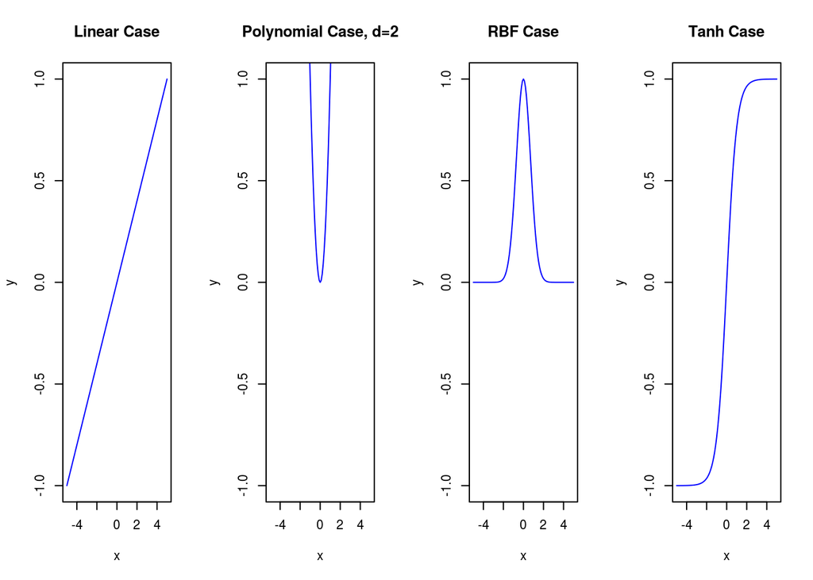

[^1]: Vladimir Vapnik & Corinna Cortes, Machine Learning, 20, 273-297, 1995
[^2]: Webster’s third new international dictionary, ISBN 0-87779-201-1, 1986
[^3]: Machine Learning, A Probabilistic Perspective, Kevin P. Murphy, MIT Press, ISBN 978-0-262-01802-9, 2012 Since the Support Vector Machines is best described by number of parameters can grow with the amount of training data, SVM is a non-parametric technique.
[^4]: Artificial Intelligence, A Modern Approach, Third Edition, Stuart Russell and Peter Norvig, Pearson, ISBN-13: 978-0-13-604259-4, 2010
[^5]: https://rpubs.com/mzc/mlwr_svm_concrete